# titanic_random_forest

```python
import pandas as pd
import numpy as np
import matplotlib.pyplot as plt
import seaborn as sns
%matplotlib inline
```

```python
train = pd.read_csv("train.csv")
test = pd.read_csv("test.csv")
```

```python
train.head()
```

|  | PassengerId | Survived | Pclass | Name | Sex | Age | SibSp | Parch | Ticket | Fare | Cabin | Embarked |
| --- | --- | --- | --- | --- | --- | --- | --- | --- | --- | --- | --- | --- |
| 0 | 1 | 0 | 3 | Braund, Mr. Owen Harris | male | 22.0 | 1 | 0 | A/5 21171 | 7.2500 | NaN | S |
| 1 | 2 | 1 | 1 | Cumings, Mrs. John Bradley (Florence Briggs Th... | female | 38.0 | 1 | 0 | PC 17599 | 71.2833 | C85 | C |
| 2 | 3 | 1 | 3 | Heikkinen, Miss. Laina | female | 26.0 | 0 | 0 | STON/O2. 3101282 | 7.9250 | NaN | S |
| 3 | 4 | 1 | 1 | Futrelle, Mrs. Jacques Heath (Lily May Peel) | female | 35.0 | 1 | 0 | 113803 | 53.1000 | C123 | S |
| 4 | 5 | 0 | 3 | Allen, Mr. William Henry | male | 35.0 | 0 | 0 | 373450 | 8.0500 | NaN | S |

```python
test.head()
```

|  | PassengerId | Pclass | Name | Sex | Age | SibSp | Parch | Ticket | Fare | Cabin | Embarked |
| --- | --- | --- | --- | --- | --- | --- | --- | --- | --- | --- | --- |
| 0 | 892 | 3 | Kelly, Mr. James | male | 34.5 | 0 | 0 | 330911 | 7.8292 | NaN | Q |
| 1 | 893 | 3 | Wilkes, Mrs. James (Ellen Needs) | female | 47.0 | 1 | 0 | 363272 | 7.0000 | NaN | S |
| 2 | 894 | 2 | Myles, Mr. Thomas Francis | male | 62.0 | 0 | 0 | 240276 | 9.6875 | NaN | Q |
| 3 | 895 | 3 | Wirz, Mr. Albert | male | 27.0 | 0 | 0 | 315154 | 8.6625 | NaN | S |
| 4 | 896 | 3 | Hirvonen, Mrs. Alexander (Helga E Lindqvist) | female | 22.0 | 1 | 1 | 3101298 | 12.2875 | NaN | S |

```python
train.info()
# Date to be imputed includes Age ,Cabin, Embarked
```

```
<class 'pandas.core.frame.DataFrame'>
RangeIndex: 891 entries, 0 to 890
Data columns (total 12 columns):
PassengerId    891 non-null int64
Survived       891 non-null int64
Pclass         891 non-null int64
Name           891 non-null object
Sex            891 non-null object
Age            714 non-null float64
SibSp          891 non-null int64
Parch          891 non-null int64
Ticket         891 non-null object
Fare           891 non-null float64
Cabin          204 non-null object
Embarked       889 non-null object
dtypes: float64(2), int64(5), object(5)
memory usage: 83.6+ KB
```

```python
test.info()
```

```
<class 'pandas.core.frame.DataFrame'>
RangeIndex: 418 entries, 0 to 417
Data columns (total 11 columns):
PassengerId    418 non-null int64
Pclass         418 non-null int64
Name           418 non-null object
Sex            418 non-null object
Age            332 non-null float64
SibSp          418 non-null int64
Parch          418 non-null int64
Ticket         418 non-null object
Fare           417 non-null float64
Cabin          91 non-null object
Embarked       418 non-null object
dtypes: float64(2), int64(4), object(5)
memory usage: 36.0+ KB
```

```python
train['source'] = "train"
test['source'] = "test"
```

```python
data = pd.concat([train, test], axis=0)
```

```python
data.info()
```

```
<class 'pandas.core.frame.DataFrame'>
Int64Index: 1309 entries, 0 to 417
Data columns (total 13 columns):
Age            1046 non-null float64
Cabin          295 non-null object
Embarked       1307 non-null object
Fare           1308 non-null float64
Name           1309 non-null object
Parch          1309 non-null int64
PassengerId    1309 non-null int64
Pclass         1309 non-null int64
Sex            1309 non-null object
SibSp          1309 non-null int64
Survived       891 non-null float64
Ticket         1309 non-null object
source         1309 non-null object
dtypes: float64(3), int64(4), object(6)
memory usage: 143.2+ KB
```

```python
data.sample(3)
```

|  | Age | Cabin | Embarked | Fare | Name | Parch | PassengerId | Pclass | Sex | SibSp | Survived | Ticket | source |
| --- | --- | --- | --- | --- | --- | --- | --- | --- | --- | --- | --- | --- | --- |
| 339 | 45.0 | T | S | 35.5000 | Blackwell, Mr. Stephen Weart | 0 | 340 | 1 | male | 0 | 0.0 | 113784 | train |
| 73 | 26.0 | NaN | C | 14.4542 | Chronopoulos, Mr. Apostolos | 0 | 74 | 3 | male | 1 | 0.0 | 2680 | train |
| 258 | 19.0 | NaN | S | 13.0000 | Bentham, Miss. Lilian W | 0 | 1150 | 2 | female | 0 | NaN | 28404 | test |

### Features

- `PassengerId` is the unique id of the row and it doesn't have any effect on target
- `Survived` is the target variable we are trying to predict (**0** or **1**):
  - **1 = Survived**
  - **0 = Not Survived**
- `Pclass` (Passenger Class) is the socio-economic status of the passenger and it is a categorical ordinal feature which has **3** unique values (**1**, **2** or **3**):
  - **1 = Upper Class**
  - **2 = Middle Class**
  - **3 = Lower Class**
- `Name`, `Sex` and `Age` are self-explanatory
- `SibSp` is the total number of the passengers' siblings and spouse
- `Parch` is the total number of the passengers' parents and children
- `Ticket` is the ticket number of the passenger
- `Fare` is the passenger fare
- `Cabin` is the cabin number of the passenger
- `Embarked` is port of embarkation and it is a categorical feature which has **3** unique values (**C**, **Q** or **S**):
  - **C = Cherbourg**
  - **Q = Queenstown**
  - **S = Southampton**

```python
def getPercentMissing(df):
    for col in df.columns:
        null_count =pd.isnull(df[col]).sum()
        per =null_count/len(df)*100
        if per != 0:
            print(f'{col} - {per} - {null_count}')
```

```python
getPercentMissing(data)
```

```
Age - 20.091673032849503 - 263
Cabin - 77.46371275783041 - 1014
Embarked - 0.15278838808250572 - 2
Fare - 0.07639419404125286 - 1
Survived - 31.932773109243694 - 418
```

```python
getPercentMissing(train)
```

```
Age - 19.865319865319865 - 177
Cabin - 77.10437710437711 - 687
Embarked - 0.22446689113355783 - 2
```

```python
getPercentMissing(test)
```

```
Age - 20.574162679425836 - 86
Fare - 0.23923444976076555 - 1
Cabin - 78.22966507177034 - 327
```

### Imputing Age

- Age is most sorrelated to pclass
- So subsituting age with median of pcalss age could be a good choice
- But we need to consider categorical features as well- Sex

```python
data.corr().abs()['Age'].sort_values(ascending= False)
```

```
Age            1.000000
Pclass         0.408106
SibSp          0.243699
Fare           0.178740
Parch          0.150917
Survived       0.077221
PassengerId    0.028814
Name: Age, dtype: float64
```

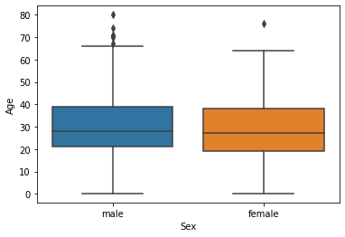

```python
sns.boxplot('Sex','Age',data = data)
```

```python
data.columns
```

```
Index(['Age', 'Cabin', 'Embarked', 'Fare', 'Name', 'Parch', 'PassengerId',
       'Pclass', 'Sex', 'SibSp', 'Survived', 'Ticket', 'source'],
      dtype='object')
```

```python
# Imputing age of Pclass and Sex
```

```python
df_age = data.groupby(by=['Pclass','Sex']).median().reset_index()[['Pclass','Sex','Age']]
df_age.head(6)
```

|  | Pclass | Sex | Age |
| --- | --- | --- | --- |
| 0 | 1 | female | 36.0 |
| 1 | 1 | male | 42.0 |
| 2 | 2 | female | 28.0 |
| 3 | 2 | male | 29.5 |
| 4 | 3 | female | 22.0 |
| 5 | 3 | male | 25.0 |

```python
m =[]
def fillMedian(x):
    a =x.fillna(x.median())
    return a
data['Age'] =data.groupby([ 'Pclass','Sex'])['Age'].transform(fillMedian)
# df['Age'] = df['value'].fillna(df.groupby([ 'Pclass','Sex'])['Age'].transform('mean'))
```

```python
getPercentMissing(data)
```

```
Cabin - 77.46371275783041 - 1014
Embarked - 0.15278838808250572 - 2
Fare - 0.07639419404125286 - 1
Survived - 31.932773109243694 - 418
```

### Imputing Embarked

```python
data[pd.isnull(data['Embarked'])]
```

|  | Age | Cabin | Embarked | Fare | Name | Parch | PassengerId | Pclass | Sex | SibSp | Survived | Ticket | source |
| --- | --- | --- | --- | --- | --- | --- | --- | --- | --- | --- | --- | --- | --- |
| 61 | 38.0 | B28 | NaN | 80.0 | Icard, Miss. Amelie | 0 | 62 | 1 | female | 0 | 1.0 | 113572 | train |
| 829 | 62.0 | B28 | NaN | 80.0 | Stone, Mrs. George Nelson (Martha Evelyn) | 0 | 830 | 1 | female | 0 | 1.0 | 113572 | train |

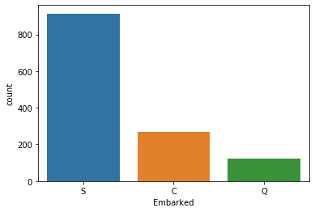

```python
sns.countplot(data['Embarked'])
```

```python
# Maximum count is in S => So we impute unknown values to S
data['Embarked'] = data['Embarked'].fillna('S')
```

### Imputing Cabin - 77.46371275783041 - 1014 missing

```python
# Taking first letter of cabin
data['Cabin_Index'] = data['Cabin'].apply(lambda s: s[0] if pd.notnull(s) else 'O')
data['Cabin_Index'].value_counts()
```

```
O    1014
C      94
B      65
D      46
E      41
A      22
F      21
G       5
T       1
Name: Cabin_Index, dtype: int64
```

```python
# Grouping cabin index with passenger class to develope some insight
class_grp =data.groupby(['Cabin_Index','Pclass']).count().reset_index().pivot_table(index="Cabin_Index", columns='Pclass', values="Name")
class_grp
```

| Pclass Cabin_Index | 1 | 2 | 3 |
| --- | --- | --- | --- |
| A | 22.0 | NaN | NaN |
| B | 65.0 | NaN | NaN |
| C | 94.0 | NaN | NaN |
| D | 40.0 | 6.0 | NaN |
| E | 34.0 | 4.0 | 3.0 |
| F | NaN | 13.0 | 8.0 |
| G | NaN | NaN | 5.0 |
| O | 67.0 | 254.0 | 693.0 |
| T | 1.0 | NaN | NaN |

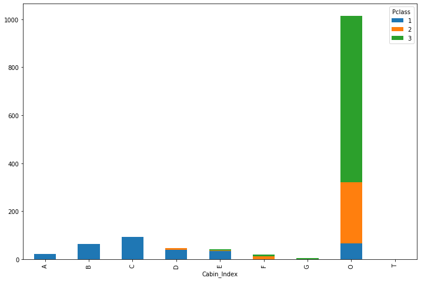

```python
class_grp.plot(kind="bar", stacked= True,figsize= (12,8))
```

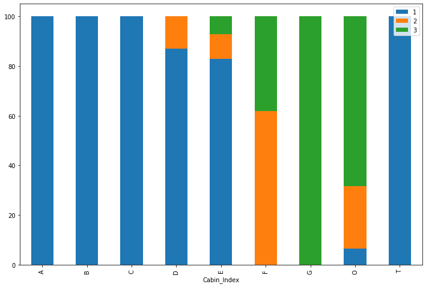

```python
# Taking percentage values of cabin allocates for each class
class_grp.fillna(0, inplace=True)
class_grp_pct = pd.DataFrame(index =class_grp.index )
cols = class_grp.columns
for i in cols:
    class_grp_pct[i] = class_grp[i]/class_grp[cols].sum(axis=1)*100
class_grp_pct.plot(kind="bar", stacked= True,figsize= (12,8))
```

```python
# Checking survival rate wrt to cabin to get some insight and group similar decks
deck_survive =data[data['source'] == "train"].groupby(['Cabin_Index','Survived']).count().reset_index().pivot_table(index="Cabin_Index", columns='Survived', values="Name")
deck_survive.fillna(0, inplace= True)
```

```python
deck_survive_pct = pd.DataFrame(index =deck_survive.index )
cols = deck_survive.columns
for i in cols:
    deck_survive_pct[i] = deck_survive[i]/deck_survive[cols].sum(axis=1)*10
deck_survive_pct
```

| Cabin_Index | 0.0 | 1.0 |
| --- | --- | --- |
| A | 5.333333 | 4.666667 |
| B | 2.553191 | 7.446809 |
| C | 4.067797 | 5.932203 |
| D | 2.424242 | 7.575758 |
| E | 2.500000 | 7.500000 |
| F | 3.846154 | 6.153846 |
| G | 5.000000 | 5.000000 |
| O | 7.001456 | 2.998544 |
| T | 10.000000 | 0.000000 |

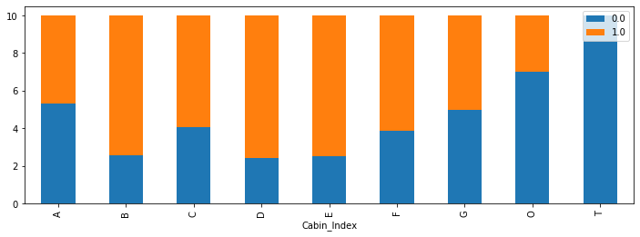

```python
deck_survive_pct.plot(kind="bar", stacked= True,figsize= (12,4))
```

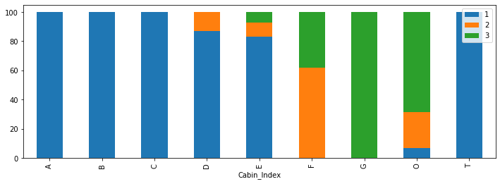

```python
class_grp_pct.plot(kind="bar", stacked= True,figsize= (12,4))
```

```python
# Processing Cabin Info
# Mapping A,B,C =>A (Ist class passengers)
# T => A (Ist class passengers)
# 0 with P1 => A
# D,E => D (same survival rates)
# F,G => F Similar surival rate
# 0 with P2,P3 =>F
# Three Cabin Info => A,D,F
```

```python
def imputeCabin(cols):
    index = cols['Cabin_Index']
    pcalss = cols['Pclass']
    if(index =="B" or index == "C" or index =="T"):
        return "A"
    elif(index == "E"):
        return "D"
    elif(index == "G"):
        return "F"
    elif(index == "O"):
        if(pcalss == 1):
            return "A"
        else:
            return "F"
    return index

data['Cabin'] = data[['Cabin_Index','Pclass']].apply(imputeCabin, axis=1)
```

```python
data['Cabin'].value_counts()
```

```
F    973
A    249
D     87
Name: Cabin, dtype: int64
```

```python
getPercentMissing(data)
```

```
Fare - 0.07639419404125286 - 1
Survived - 31.932773109243694 - 418
```

```python
# Imputing one fare value missing => avergae p3 fare value
```

```python
data[pd.isnull(data['Fare'])]
```

|  | Age | Cabin | Embarked | Fare | Name | Parch | PassengerId | Pclass | Sex | SibSp | Survived | Ticket | source | Cabin_Index |
| --- | --- | --- | --- | --- | --- | --- | --- | --- | --- | --- | --- | --- | --- | --- |
| 152 | 60.5 | F | S | NaN | Storey, Mr. Thomas | 0 | 1044 | 3 | male | 0 | NaN | 3701 | test | O |

```python
data.corr().abs()['Fare'].sort_values(ascending = False)
# High correlation with class
```

```
Fare           1.000000
Pclass         0.558629
Survived       0.257307
Parch          0.221539
Age            0.200039
SibSp          0.160238
PassengerId    0.031428
Name: Fare, dtype: float64
```

```python
mean_fare_p3 =data[data['Pclass'] ==3]['Fare'].mean()
```

```python
data['Fare'] = data['Fare'].fillna(mean_fare_p3)
```

```python
getPercentMissing(data)
```

```
Survived - 31.932773109243694 - 418
```

```python
# There is no more missing values here. We can start with feature engineering
# Starting here with contious features to see distribution to be converted to
# bins
```

```python
train_df = data[data['source']== 'train']
test_df = data[data['source']== 'test']
```

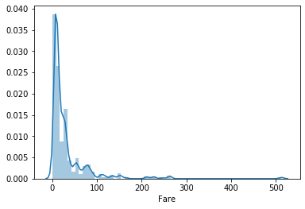

```python
sns.distplot(train_df['Fare'],bins =60,hist=True)
```

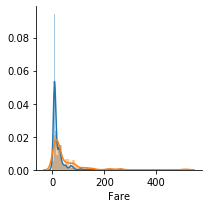

```python
plt.figure(figsize= (12,8))
f =sns.FacetGrid(train_df, hue="Survived")
f.map(sns.distplot, 'Fare')
```

```python
def PlotDist(df, label, hue="Survived"):
    f =sns.FacetGrid(df, hue=hue,size=4, aspect=5)
    f.map(sns.distplot, label,bins =20)
    f.add_legend()
```

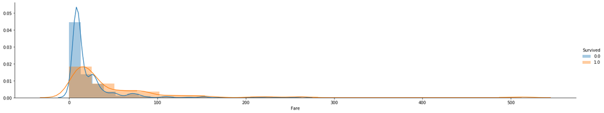

```python
PlotDist(train_df, 'Fare')
```

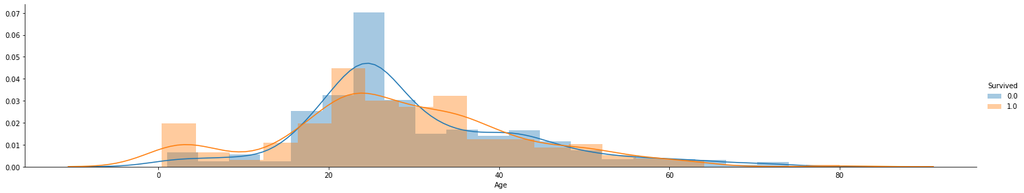

```python
PlotDist(train_df, 'Age')
```

```python
# pd.qcut(data['Age'], 10)
# pd.qcut(data['Fare'], 10)
# BIN AGE
# LABEL ENCODER
# BIN Fare
# LABEL ENCODER
```

### Converting continous features in to bins

- Age is converted to 10 bins using qcut
- Fare is also converted to 10 bins

```python
data['Age'] = pd.qcut(data['Age'], 10)
data['Fare'] = pd.qcut(data['Fare'], 10)
```

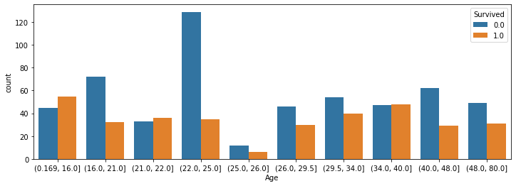

```python
plt.figure(figsize=(12,4))
sns.countplot("Age", hue="Survived", data = data)
```

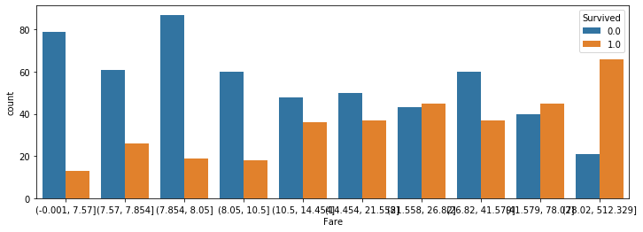

```python
plt.figure(figsize=(12,4))
sns.countplot("Fare", hue="Survived", data = data)
# Higher fare has best survival rates
```

### Interpreting size of family

SibSp is the total number of the passengers' siblings and spouse Parch is the total number of the passengers' parents and children

```python
data.head()
```

|  | Age | Cabin | Embarked | Fare | Name | Parch | PassengerId | Pclass | Sex | SibSp | Survived | Ticket | source | Cabin_Index |
| --- | --- | --- | --- | --- | --- | --- | --- | --- | --- | --- | --- | --- | --- | --- |
| 0 | (21.0, 22.0] | F | S | (-0.001, 7.57] | Braund, Mr. Owen Harris | 0 | 1 | 3 | male | 1 | 0.0 | A/5 21171 | train | O |
| 1 | (34.0, 40.0] | A | C | (41.579, 78.02] | Cumings, Mrs. John Bradley (Florence Briggs Th... | 0 | 2 | 1 | female | 1 | 1.0 | PC 17599 | train | C |
| 2 | (25.0, 26.0] | F | S | (7.854, 8.05] | Heikkinen, Miss. Laina | 0 | 3 | 3 | female | 0 | 1.0 | STON/O2. 3101282 | train | O |
| 3 | (34.0, 40.0] | A | S | (41.579, 78.02] | Futrelle, Mrs. Jacques Heath (Lily May Peel) | 0 | 4 | 1 | female | 1 | 1.0 | 113803 | train | C |
| 4 | (34.0, 40.0] | F | S | (7.854, 8.05] | Allen, Mr. William Henry | 0 | 5 | 3 | male | 0 | 0.0 | 373450 | train | O |

```python
data['Family'] = data['SibSp'] + data['Parch']
```

```python
data['Family'].value_counts()
```

```
0     790
1     235
2     159
3      43
5      25
4      22
6      16
10     11
7       8
Name: Family, dtype: int64
```

```python
data.info()
```

```
<class 'pandas.core.frame.DataFrame'>
Int64Index: 1309 entries, 0 to 417
Data columns (total 15 columns):
Age            1309 non-null category
Cabin          1309 non-null object
Embarked       1309 non-null object
Fare           1309 non-null category
Name           1309 non-null object
Parch          1309 non-null int64
PassengerId    1309 non-null int64
Pclass         1309 non-null int64
Sex            1309 non-null object
SibSp          1309 non-null int64
Survived       891 non-null float64
Ticket         1309 non-null object
source         1309 non-null object
Cabin_Index    1309 non-null object
Family         1309 non-null int64
dtypes: category(2), float64(1), int64(5), object(7)
memory usage: 186.0+ KB
```

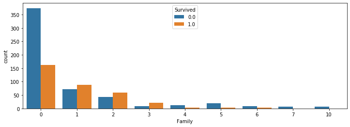

```python
#survival rate vs family members count
plt.figure(figsize=(12,4))
sns.countplot('Family', data= data[data['source'] == 'train'], hue="Survived")
# Survival rate is different for diiferent family counts
```

### Grouping family members

- 0
- 1,2,3 => similar survival rates
- 4,5,6 => Similar survival rates
- 7,10 => Same rate #### Converting to labels 0,1,2,3|

```python
def groupFamilyCount(val):
    if(val >0 and val <4):
        return 1
    elif(val>3 and val <7):
        return 2
    elif(val > 6):
        return 3
    return val
data['Family'] = data['Family'].apply(groupFamilyCount)
```

```python
data['Family'].value_counts()
```

```
0    790
1    437
2     63
3     19
Name: Family, dtype: int64
```

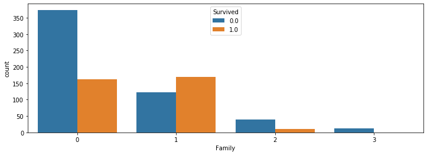

```python
plt.figure(figsize=(12,4))
sns.countplot('Family', data= data[data['source'] == 'train'], hue="Survived")
```

```python
# Ticket
# Ticket may have high correlation with family size , so is ignored
```

### Trying to derive feature from Name

There is no direct information other than to compare family name and group based on survival rates

```python
data['Name'].tail()
```

```
413              Spector, Mr. Woolf
414    Oliva y Ocana, Dona. Fermina
415    Saether, Mr. Simon Sivertsen
416             Ware, Mr. Frederick
417        Peter, Master. Michael J
Name: Name, dtype: object
```

```python
data['LastName'] = data['Name'].apply(lambda x: x.split(',')[0])
```

```python
data.groupby(['LastName','Survived']).count().head()
```

| LastName | Survived | Age | Cabin | Embarked | Fare | Name | Parch | PassengerId | Pclass | Sex | SibSp | Ticket | source | Cabin_Index | Family |
| --- | --- | --- | --- | --- | --- | --- | --- | --- | --- | --- | --- | --- | --- | --- | --- |
| Abbing | 0.0 | 1 | 1 | 1 | 1 | 1 | 1 | 1 | 1 | 1 | 1 | 1 | 1 | 1 | 1 |
| Abbott | 0.0 | 1 | 1 | 1 | 1 | 1 | 1 | 1 | 1 | 1 | 1 | 1 | 1 | 1 | 1 |
|  | 1.0 | 1 | 1 | 1 | 1 | 1 | 1 | 1 | 1 | 1 | 1 | 1 | 1 | 1 | 1 |
| Abelson | 0.0 | 1 | 1 | 1 | 1 | 1 | 1 | 1 | 1 | 1 | 1 | 1 | 1 | 1 | 1 |
|  | 1.0 | 1 | 1 | 1 | 1 | 1 | 1 | 1 | 1 | 1 | 1 | 1 | 1 | 1 | 1 |

```python
# It could be error prone because survival rate will be 0, for family names not in train data
# So ignore last name
# Analyze survival rates based on titles could be a viable feature
```

```python
data['title'] = data['Name'].apply(lambda x: x.split(',')[1].split('.')[0].strip())
```

```python
data['title'].value_counts()
```

```
Mr              757
Miss            260
Mrs             197
Master           61
Dr                8
Rev               8
Col               4
Mlle              2
Ms                2
Major             2
Mme               1
the Countess      1
Don               1
Sir               1
Jonkheer          1
Capt              1
Lady              1
Dona              1
Name: title, dtype: int64
```

```python
title_missing =data[data.title.isin(['Mlle','Dona','Jonkheer','Don','Mme'])]
title_missing
```

|  | Age | Cabin | Embarked | Fare | Name | Parch | PassengerId | Pclass | Sex | SibSp | Survived | Ticket | source | Cabin_Index | Family | LastName | title |
| --- | --- | --- | --- | --- | --- | --- | --- | --- | --- | --- | --- | --- | --- | --- | --- | --- | --- |
| 30 | (34.0, 40.0] | A | C | (26.82, 41.579] | Uruchurtu, Don. Manuel E | 0 | 31 | 1 | male | 0 | 0.0 | PC 17601 | train | O | 0 | Uruchurtu | Don |
| 369 | (22.0, 25.0] | A | C | (41.579, 78.02] | Aubart, Mme. Leontine Pauline | 0 | 370 | 1 | female | 0 | 1.0 | PC 17477 | train | B | 0 | Aubart | Mme |
| 641 | (22.0, 25.0] | A | C | (41.579, 78.02] | Sagesser, Mlle. Emma | 0 | 642 | 1 | female | 0 | 1.0 | PC 17477 | train | B | 0 | Sagesser | Mlle |
| 710 | (22.0, 25.0] | A | C | (41.579, 78.02] | Mayne, Mlle. Berthe Antonine ("Mrs de Villiers") | 0 | 711 | 1 | female | 0 | 1.0 | PC 17482 | train | C | 0 | Mayne | Mlle |
| 822 | (34.0, 40.0] | A | S | (-0.001, 7.57] | Reuchlin, Jonkheer. John George | 0 | 823 | 1 | male | 0 | 0.0 | 19972 | train | O | 0 | Reuchlin | Jonkheer |
| 414 | (34.0, 40.0] | A | C | (78.02, 512.329] | Oliva y Ocana, Dona. Fermina | 0 | 1306 | 1 | female | 0 | NaN | PC 17758 | test | C | 0 | Oliva y Ocana | Dona |

```python
imputed_title = data[data.title.isin(['Mlle','Dona','Jonkheer','Don','Mme'])]['Sex'].apply(lambda x: 'Mr' if x == "male" else 'Mrs')
```

```python
data.loc[title_missing.index, ['title']] = imputed_title
```

```python
data['title'].value_counts()
```

```
Mr              757
Miss            260
Mrs             203
Master           61
Rev               8
Dr                8
Col               4
Major             2
Ms                2
Sir               1
Lady              1
Capt              1
the Countess      1
Name: title, dtype: int64
```

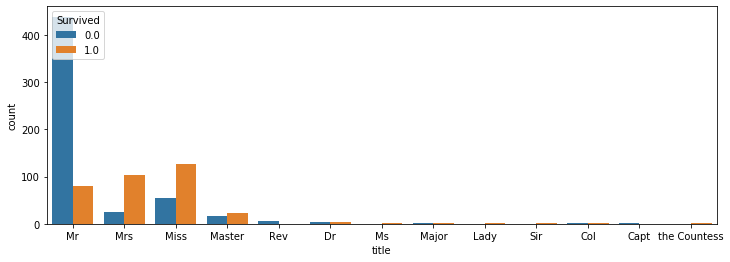

```python
plt.figure(figsize=(12,4))
train_df = data[data['source'] == "train"]
sns.countplot(train_df['title'], hue = train_df['Survived'])
```

```python
#pd.DataFrame(train_df.groupby(['title', 'Survived']).count()['Name'])
```

### Add Mrs, Miss, Ms, Lady, 'countess'

- Mr + all miscelaneous group
- Master
- Master title has better survival rate than Mr
- Mr, Mrs is capture in Sex Fiels
- We will define new fearure called isMaster to consider this

```python
data['isMaster'] = (data['title'] =="Master").astype(int)
```

### Encoding features and transforming

```python
data.head(2)
```

|  | Age | Cabin | Embarked | Fare | Name | Parch | PassengerId | Pclass | Sex | SibSp | Survived | Ticket | source | Cabin_Index | Family | LastName | title | isMaster |
| --- | --- | --- | --- | --- | --- | --- | --- | --- | --- | --- | --- | --- | --- | --- | --- | --- | --- | --- |
| 0 | (21.0, 22.0] | F | S | (-0.001, 7.57] | Braund, Mr. Owen Harris | 0 | 1 | 3 | male | 1 | 0.0 | A/5 21171 | train | O | 1 | Braund | Mr | 0 |
| 1 | (34.0, 40.0] | A | C | (41.579, 78.02] | Cumings, Mrs. John Bradley (Florence Briggs Th... | 0 | 2 | 1 | female | 1 | 1.0 | PC 17599 | train | C | 1 | Cumings | Mrs | 0 |

```python
data.columns
```

```
Index(['Age', 'Cabin', 'Embarked', 'Fare', 'Name', 'Parch', 'PassengerId',
       'Pclass', 'Sex', 'SibSp', 'Survived', 'Ticket', 'source', 'Cabin_Index',
       'Family', 'LastName', 'title', 'isMaster'],
      dtype='object')
```

#### Features to be label encoded => convert to 0=> N-1

- Age, Fare are increasing in the same value as the actual one's (ordinal)
- So we DONT need to one hot encode them

```python
label_features = ['Age','Fare','Sex']
from sklearn.preprocessing import LabelEncoder, OneHotEncoder

for feature in label_features:
    le = LabelEncoder()
    data[feature] = le.fit_transform(data[feature])
```

### Features to apply one hot encoding

```python
cat_features =['Cabin','Embarked','Pclass','Family']
dummies =pd.get_dummies(data[cat_features].astype(str))
```

```python
df = pd.concat([data, dummies], axis=1)
df.head(2)
```

|  | Age | Cabin | Embarked | Fare | Name | Parch | PassengerId | Pclass | Sex | SibSp | ... | Embarked_C | Embarked_Q | Embarked_S | Pclass_1 | Pclass_2 | Pclass_3 | Family_0 | Family_1 | Family_2 | Family_3 |
| --- | --- | --- | --- | --- | --- | --- | --- | --- | --- | --- | --- | --- | --- | --- | --- | --- | --- | --- | --- | --- | --- |
| 0 | 2 | F | S | 0 | Braund, Mr. Owen Harris | 0 | 1 | 3 | 1 | 1 | ... | 0 | 0 | 1 | 0 | 0 | 1 | 0 | 1 | 0 | 0 |
| 1 | 7 | A | C | 8 | Cumings, Mrs. John Bradley (Florence Briggs Th... | 0 | 2 | 1 | 0 | 1 | ... | 1 | 0 | 0 | 1 | 0 | 0 | 0 | 1 | 0 | 0 |

2 rows × 31 columns

```python
data.columns
```

```
Index(['Age', 'Cabin', 'Embarked', 'Fare', 'Name', 'Parch', 'PassengerId',
       'Pclass', 'Sex', 'SibSp', 'Survived', 'Ticket', 'source', 'Cabin_Index',
       'Family', 'LastName', 'title', 'isMaster'],
      dtype='object')
```

```python
num_features =['Age','Fare','isMaster','Sex']
# Features to train
features= np.concatenate((dummies.columns,num_features))
```

```python
features
```

```
array(['Cabin_A', 'Cabin_D', 'Cabin_F', 'Embarked_C', 'Embarked_Q',
       'Embarked_S', 'Pclass_1', 'Pclass_2', 'Pclass_3', 'Family_0',
       'Family_1', 'Family_2', 'Family_3', 'Age', 'Fare', 'isMaster',
       'Sex'], dtype=object)
```

```python
df[features].head()
```

|  | Cabin_A | Cabin_D | Cabin_F | Embarked_C | Embarked_Q | Embarked_S | Pclass_1 | Pclass_2 | Pclass_3 | Family_0 | Family_1 | Family_2 | Family_3 | Age | Fare | isMaster | Sex |
| --- | --- | --- | --- | --- | --- | --- | --- | --- | --- | --- | --- | --- | --- | --- | --- | --- | --- |
| 0 | 0 | 0 | 1 | 0 | 0 | 1 | 0 | 0 | 1 | 0 | 1 | 0 | 0 | 2 | 0 | 0 | 1 |
| 1 | 1 | 0 | 0 | 1 | 0 | 0 | 1 | 0 | 0 | 0 | 1 | 0 | 0 | 7 | 8 | 0 | 0 |
| 2 | 0 | 0 | 1 | 0 | 0 | 1 | 0 | 0 | 1 | 1 | 0 | 0 | 0 | 4 | 2 | 0 | 0 |
| 3 | 1 | 0 | 0 | 0 | 0 | 1 | 1 | 0 | 0 | 0 | 1 | 0 | 0 | 7 | 8 | 0 | 0 |
| 4 | 0 | 0 | 1 | 0 | 0 | 1 | 0 | 0 | 1 | 1 | 0 | 0 | 0 | 7 | 2 | 0 | 1 |

### Features seems to be compareable so no need to use Scaling

- Atlest that is the assumption

```python
from sklearn.model_selection import train_test_split
train = df[df['source'] == "train"]
test = df[df['source'] == "test"]
X = train[features].values
y = train['Survived'].values
X_train, X_test, y_train, y_test = train_test_split(X, y, test_size=0.20, random_state=42)
```

```python
print(X_train.shape)
print(y_train.shape)
print(X_test.shape)
```

```
(712, 17)
(712,)
(179, 17)
```

### Use RandomizedSearchCV for getting optimal params

```python
from sklearn.model_selection import RandomizedSearchCV,GridSearchCV
```

```python
max_depth= [5, 10, 30, 50, 80, 100]
max_features=  ['auto', 'sqrt']
min_samples_leaf= [ 4,6, 8]
min_samples_split= [2, 5, 10]
n_estimators= [500,  1000, 1500, 2000]
```

```python
random_grid = {'n_estimators': n_estimators,
               'max_features': max_features,
               'max_depth': max_depth,
               'min_samples_split': min_samples_split,
               'min_samples_leaf': min_samples_leaf
               }

rf = RandomForestClassifier(criterion='gini',
               bootstrap= True,
               oob_score=True,
               random_state=42,
               n_jobs=-1,
               verbose=1)
rf_random = RandomizedSearchCV(estimator = rf, param_distributions = random_grid, n_iter = 100, cv = 3, verbose=-1, random_state=42, n_jobs = -1)
search =rf_random.fit(X_train, y_train)
```

[output not shown]

```python
search.best_params_
```

```
{'n_estimators': 1500,
 'min_samples_split': 10,
 'min_samples_leaf': 4,
 'max_features': 'sqrt',
 'max_depth': 5}
```

```python
search.best_estimator_.oob_score_
```

```
0.8188202247191011
```

```python
# Defining new params
```

```python
max_depth= [3,5,7]
min_samples_leaf= [ 2,4,5]
min_samples_split= [8,10,12]
#n_estimators= [750,  1000, 1250]
n_estimators= [1250,  1500, 1750]
```

```python
param_grid = {'n_estimators': n_estimators,
               'max_depth': max_depth,
               'min_samples_split': min_samples_split,
               'min_samples_leaf': min_samples_leaf
               }

rf = RandomForestClassifier(criterion='gini',
               bootstrap= True,
               oob_score=True,
               random_state=42,
               max_features='auto',
               n_jobs=-1,
               verbose=1)
rf_grid = GridSearchCV(estimator = rf, param_grid = param_grid, cv = 3, verbose=-1, n_jobs = -1)
grid_search =rf_grid.fit(X_train, y_train)
```

[output not shown]

```python
grid_search.best_params_
```

```
{'max_depth': 5,
 'min_samples_leaf': 2,
 'min_samples_split': 12,
 'n_estimators': 1750}
```

```python
model = grid_search.best_estimator_
```

```python
model.oob_score_
```

```
0.824438202247191
```

```python
from sklearn.metrics import classification_report, confusion_matrix
```

```python
y_pred = model.predict(X_test)
```

[output not shown]

```python
print(classification_report(y_test, y_pred))
print(confusion_matrix(y_test, y_pred))
```

```
              precision    recall  f1-score   support

         0.0       0.82      0.90      0.86       105
         1.0       0.83      0.73      0.78        74

    accuracy                           0.83       179
   macro avg       0.83      0.81      0.82       179
weighted avg       0.83      0.83      0.82       179

[[94 11]
 [20 54]]
```

```python
feature_imp = pd.DataFrame({'feat': features, 'score':model.feature_importances_}).sort_values(by="score",ascending=False)
```

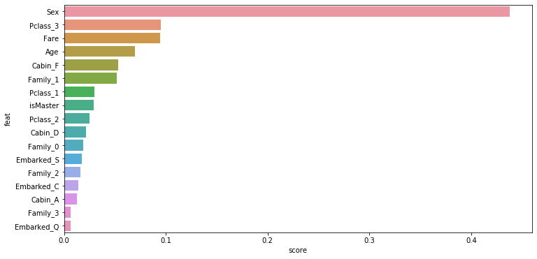

```python
plt.figure(figsize=(12,6))
sns.barplot(y="feat", x="score", data =feature_imp)
```